# Life Expectancy: Females versus Males

Saghir Bashir

Fri 02 Oct 2020 (16:44:33)

# Understanding the data

## Data Limitations

# Questions to Answer

Answer the following questions using the female and male life expectancy data:

1. By continent and sex, which countries have the lowest and highest life expectancy in 1960 and 2018?
2. How does Portugal compare to other EU Countries by sex?
3. How does Portugal compare to other lusophone countries (e.g. Angola, Brazil) by sex?

# Load Packages

```r
library(knitr)
library(kableExtra)
library(ggplot2)
library(magrittr)
library(data.table)
library(here)
library(countrycode)
```

# Data Processing

## Continent data

```r
# Country Code data
cl <-  as.data.table(codelist)[, .(wb, continent)]
```

## Life Expectancy Data

### Import Original (Wide) Female Data

- **Exercise**
  1. Import female data into dataset `fwble`.
  2. Create a new variable called `Sex` with value `"Female"`.
  3. Delete unnecessary variable.
  4. Rename variables.

**… Write your R code here …**

#### Summaries to compare your output

```r
str(fwble, list.len=8)
## Classes 'data.table' and 'data.frame':   264 obs. of  63 variables:
##  $ Country: chr  "Aruba" "Afghanistan" "Angola" "Albania" ...
##  $ Code   : chr  "ABW" "AFG" "AGO" "ALB" ...
##  $ X1960  : num  67.1 33.3 38.8 63.2 NA ...
##  $ X1961  : num  67.6 33.8 39.1 64.3 NA ...
##  $ X1962  : num  68.1 34.4 39.4 65.3 NA ...
##  $ X1963  : num  68.5 34.9 39.7 66 NA ...
##  $ X1964  : num  68.8 35.4 40.1 66.6 NA ...
##  $ X1965  : num  69.2 35.9 40.4 67 NA ...
##   [list output truncated]
##  - attr(*, ".internal.selfref")=<externalptr>
head(names(fwble))
## [1] "Country" "Code"    "X1960"   "X1961"   "X1962"   "X1963"
tail(names(fwble))
## [1] "X2015" "X2016" "X2017" "X2018" "X2019" "Sex"
```

### Import Original (Wide) Male Data

**… Write your R code here …**

#### Summaries to compare your output

```r
str(mwble, list.len=8)
## Classes 'data.table' and 'data.frame':   264 obs. of  63 variables:
##  $ Country: chr  "Aruba" "Afghanistan" "Angola" "Albania" ...
##  $ Code   : chr  "ABW" "AFG" "AGO" "ALB" ...
##  $ X1960  : num  64.1 31.7 36.3 61.3 NA ...
##  $ X1961  : num  64.4 32.2 36.6 62.3 NA ...
##  $ X1962  : num  64.7 32.7 36.9 63.1 NA ...
##  $ X1963  : num  65.1 33.2 37.2 63.8 NA ...
##  $ X1964  : num  65.4 33.7 37.5 64.3 NA ...
##  $ X1965  : num  65.7 34.2 37.8 64.7 NA ...
##   [list output truncated]
##  - attr(*, ".internal.selfref")=<externalptr>
head(names(mwble))
## [1] "Country" "Code"    "X1960"   "X1961"   "X1962"   "X1963"
tail(names(mwble))
## [1] "X2015" "X2016" "X2017" "X2018" "X2019" "Sex"
```

### Combine Female and Male Data into One Dataset

Using the `rbindlist()` function from the `data.table` we can “append” the female and male life expectancy dataset into one dataset.

```r
# Append the two datasets
wble <- rbindlist(list(fwble, mwble))

# Check with `fwble` and `mwble` that the number of observations is correct.
str(wble, list.len=8)
## Classes 'data.table' and 'data.frame':   528 obs. of  63 variables:
##  $ Country: chr  "Aruba" "Afghanistan" "Angola" "Albania" ...
##  $ Code   : chr  "ABW" "AFG" "AGO" "ALB" ...
##  $ X1960  : num  67.1 33.3 38.8 63.2 NA ...
##  $ X1961  : num  67.6 33.8 39.1 64.3 NA ...
##  $ X1962  : num  68.1 34.4 39.4 65.3 NA ...
##  $ X1963  : num  68.5 34.9 39.7 66 NA ...
##  $ X1964  : num  68.8 35.4 40.1 66.6 NA ...
##  $ X1965  : num  69.2 35.9 40.4 67 NA ...
##   [list output truncated]
##  - attr(*, ".internal.selfref")=<externalptr>

# Check the first and last variable names
head(names(wble))
## [1] "Country" "Code"    "X1960"   "X1961"   "X1962"   "X1963"
tail(names(wble))
## [1] "X2015" "X2016" "X2017" "X2018" "X2019" "Sex"

# Check Sex variable
wble[, .(N=.N), .(Sex)]
##       Sex   N
## 1: Female 264
## 2:   Male 264
```

### Wide to Long Format

- **Exercise**
  1. Melt the data by `Country`, `Code` and `Sex`.
  2. Convert Year to numeric.
  3. Merge `Continent` column.
  4. Set column order.
  5. Set row order.

**… Write your R code here …**

### Long Life Expectancy Dataset

The `le` is the final dataset. Compare your dataset to the information below. Do they match?

```r
# Review the structure
str(le)
## Classes 'data.table' and 'data.frame':   22868 obs. of  6 variables:
##  $ Continent: chr  "Africa" "Africa" "Africa" "Africa" ...
##  $ Country  : chr  "Algeria" "Algeria" "Algeria" "Algeria" ...
##  $ Code     : chr  "DZA" "DZA" "DZA" "DZA" ...
##  $ Year     : num  1960 1960 1961 1961 1962 ...
##  $ lifeExp  : num  46.9 45.4 47.3 45.9 47.8 ...
##  $ Sex      : chr  "Female" "Male" "Female" "Male" ...
##  - attr(*, ".internal.selfref")=<externalptr>
##  - attr(*, "sorted")= chr [1:3] "Continent" "Country" "Year"

# Looking at the dataset
le
##        Continent Country Code Year lifeExp    Sex
##     1:    Africa Algeria  DZA 1960  46.865 Female
##     2:    Africa Algeria  DZA 1960  45.440   Male
##     3:    Africa Algeria  DZA 1961  47.333 Female
##     4:    Africa Algeria  DZA 1961  45.883   Male
##     5:    Africa Algeria  DZA 1962  47.801 Female
##    ---
## 22864:   Oceania Vanuatu  VUT 2016  68.544   Male
## 22865:   Oceania Vanuatu  VUT 2017  71.830 Female
## 22866:   Oceania Vanuatu  VUT 2017  68.699   Male
## 22867:   Oceania Vanuatu  VUT 2018  71.990 Female
## 22868:   Oceania Vanuatu  VUT 2018  68.847   Male
```

# Question 1: By continent and sex, which countries have the lowest and highest life expectancy in 1960 and 2018?

## Lowest life Expectancy

**… Write your R code here …**

```
##     Continent    Sex Year                  Country Code lifeExp
##  1:    Africa Female 1960                     Mali  MLI  29.026
##  2:    Africa Female 2018 Central African Republic  CAF  54.991
##  3:    Africa   Male 1960                     Mali  MLI  27.436
##  4:    Africa   Male 2018                  Lesotho  LSO  50.582
##  5:  Americas Female 1960                  Bolivia  BOL  43.128
##  6:  Americas Female 2018                    Haiti  HTI  65.832
##  7:  Americas   Male 1960                    Haiti  HTI  40.315
##  8:  Americas   Male 2018                    Haiti  HTI  61.500
##  9:      Asia Female 1960              Yemen, Rep.  YEM  31.062
## 10:      Asia Female 2018              Afghanistan  AFG  66.026
## 11:      Asia   Male 1960              Yemen, Rep.  YEM  28.838
## 12:      Asia   Male 2018              Afghanistan  AFG  63.047
## 13:    Europe Female 1960          North Macedonia  MKD  61.072
## 14:    Europe Female 2018                  Moldova  MDA  76.074
## 15:    Europe   Male 1960                  Moldova  MDA  58.024
## 16:    Europe   Male 2018                  Ukraine  UKR  66.690
## 17:   Oceania Female 1960         Papua New Guinea  PNG  39.515
## 18:   Oceania Female 2018         Papua New Guinea  PNG  65.576
## 19:   Oceania   Male 1960         Papua New Guinea  PNG  38.449
## 20:   Oceania   Male 2018         Papua New Guinea  PNG  63.039
```

```
##     Year Continent    Sex                  Country Code lifeExp
##  1: 1960    Africa Female                     Mali  MLI  29.026
##  2: 1960    Africa   Male                     Mali  MLI  27.436
##  3: 1960  Americas Female                  Bolivia  BOL  43.128
##  4: 1960  Americas   Male                    Haiti  HTI  40.315
##  5: 1960      Asia Female              Yemen, Rep.  YEM  31.062
##  6: 1960      Asia   Male              Yemen, Rep.  YEM  28.838
##  7: 1960    Europe Female          North Macedonia  MKD  61.072
##  8: 1960    Europe   Male                  Moldova  MDA  58.024
##  9: 1960   Oceania Female         Papua New Guinea  PNG  39.515
## 10: 1960   Oceania   Male         Papua New Guinea  PNG  38.449
## 11: 2018    Africa Female Central African Republic  CAF  54.991
## 12: 2018    Africa   Male                  Lesotho  LSO  50.582
## 13: 2018  Americas Female                    Haiti  HTI  65.832
## 14: 2018  Americas   Male                    Haiti  HTI  61.500
## 15: 2018      Asia Female              Afghanistan  AFG  66.026
## 16: 2018      Asia   Male              Afghanistan  AFG  63.047
## 17: 2018    Europe Female                  Moldova  MDA  76.074
## 18: 2018    Europe   Male                  Ukraine  UKR  66.690
## 19: 2018   Oceania Female         Papua New Guinea  PNG  65.576
## 20: 2018   Oceania   Male         Papua New Guinea  PNG  63.039
```

## Highest life Expectancy

**… Write your R code here …**

```
##     Continent    Sex Year              Country Code lifeExp
##  1:    Africa Female 1960            Mauritius  MUS  60.626
##  2:    Africa   Male 1960            Mauritius  MUS  56.954
##  3:    Africa Female 2018              Tunisia  TUN  78.536
##  4:    Africa   Male 2018              Algeria  DZA  75.494
##  5:  Americas Female 1960               Canada  CAN  74.150
##  6:  Americas   Male 1960               Canada  CAN  68.260
##  7:  Americas Female 2018              Bermuda  BMU  85.570
##  8:  Americas   Male 2018               Canada  CAN  79.900
##  9:      Asia Female 1960               Cyprus  CYP  71.655
## 10:      Asia   Male 1960               Cyprus  CYP  67.625
## 11:      Asia Female 2018 Hong Kong SAR, China  HKG  87.700
## 12:      Asia   Male 2018 Hong Kong SAR, China  HKG  82.300
## 13:    Europe Female 1960               Norway  NOR  75.870
## 14:    Europe   Male 1960          Netherlands  NLD  71.500
## 15:    Europe Female 2018                Spain  ESP  86.300
## 16:    Europe   Male 2018          Switzerland  CHE  81.900
## 17:   Oceania Female 1960            Australia  AUS  74.000
## 18:   Oceania   Male 1960          New Zealand  NZL  68.700
## 19:   Oceania Female 2018            Australia  AUS  84.900
## 20:   Oceania   Male 2018            Australia  AUS  80.700
```

```
##     Year Continent    Sex              Country Code lifeExp
##  1: 1960    Africa Female            Mauritius  MUS  60.626
##  2: 1960    Africa   Male            Mauritius  MUS  56.954
##  3: 1960  Americas Female               Canada  CAN  74.150
##  4: 1960  Americas   Male               Canada  CAN  68.260
##  5: 1960      Asia Female               Cyprus  CYP  71.655
##  6: 1960      Asia   Male               Cyprus  CYP  67.625
##  7: 1960    Europe Female               Norway  NOR  75.870
##  8: 1960    Europe   Male          Netherlands  NLD  71.500
##  9: 1960   Oceania Female            Australia  AUS  74.000
## 10: 1960   Oceania   Male          New Zealand  NZL  68.700
## 11: 2018    Africa Female              Tunisia  TUN  78.536
## 12: 2018    Africa   Male              Algeria  DZA  75.494
## 13: 2018  Americas Female              Bermuda  BMU  85.570
## 14: 2018  Americas   Male               Canada  CAN  79.900
## 15: 2018      Asia Female Hong Kong SAR, China  HKG  87.700
## 16: 2018      Asia   Male Hong Kong SAR, China  HKG  82.300
## 17: 2018    Europe Female                Spain  ESP  86.300
## 18: 2018    Europe   Male          Switzerland  CHE  81.900
## 19: 2018   Oceania Female            Australia  AUS  84.900
## 20: 2018   Oceania   Male            Australia  AUS  80.700
```

# Q2: What are the time trends for Portugal and other EU countries by sex?

**Assumption:** It is assumed that EU means Europe and not European Union.

## Plot - Facet by Country

**… Write your R code here …**

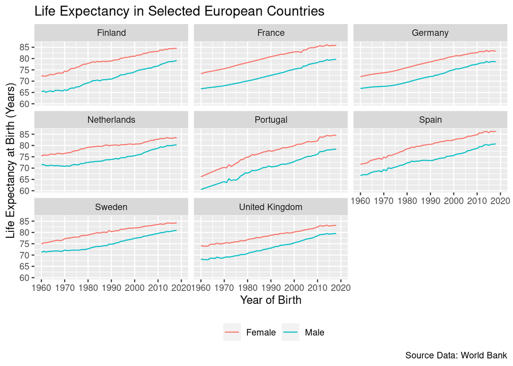

## Plot - Facet by Sex

**… Write your R code here …**

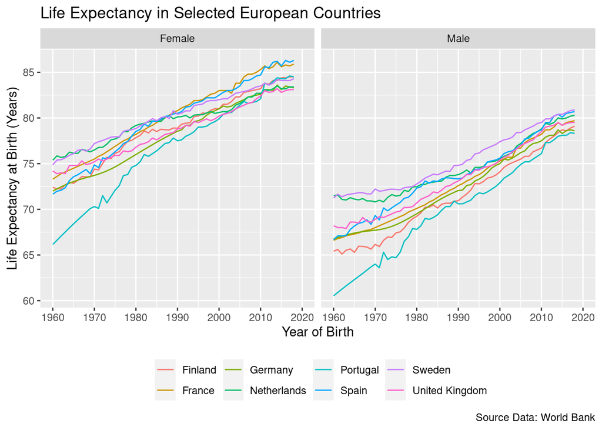

## Table - Spread by Year

**… Write your R code here …**

| Country | Female_1960 | Female_2018 | Male_1960 | Male_2018 |
| --- | --- | --- | --- | --- |
| Finland | 72.4 | 84.5 | 65.4 | 79.1 |
| France | 73.3 | 85.9 | 66.6 | 79.7 |
| Germany | 72.0 | 83.3 | 66.8 | 78.6 |
| Netherlands | 75.4 | 83.4 | 71.5 | 80.3 |
| Portugal | 66.2 | 84.5 | 60.5 | 78.3 |
| Spain | 71.7 | 86.3 | 66.7 | 80.7 |
| Sweden | 74.9 | 84.3 | 71.2 | 80.9 |
| United Kingdom | 74.2 | 83.1 | 68.2 | 79.5 |

## Table - Spread by Country

**… Write your R code here …**

| Sex | Year | Finland | France | Germany | Netherlands | Portugal | Spain | Sweden | United Kingdom |
| --- | --- | --- | --- | --- | --- | --- | --- | --- | --- |
| Female | 1960 | 72.4 | 73.3 | 72.0 | 75.4 | 66.2 | 71.7 | 74.9 | 74.2 |
| Female | 2018 | 84.5 | 85.9 | 83.3 | 83.4 | 84.5 | 86.3 | 84.3 | 83.1 |
| Male | 1960 | 65.4 | 66.6 | 66.8 | 71.5 | 60.5 | 66.7 | 71.2 | 68.2 |
| Male | 2018 | 79.1 | 79.7 | 78.6 | 80.3 | 78.3 | 80.7 | 80.9 | 79.5 |

## Interpretation

# Q3: How does Portugal compare to other lusophone countries (e.g. Angola, Brazil) by sex?

## Plot - Facet by Country

**… Write your R code here …**

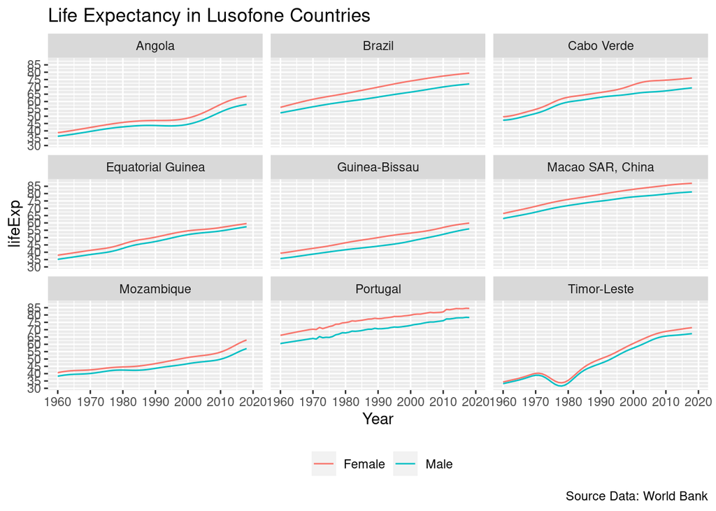

## Plot - Facet by Sex

**… Write your R code here …**

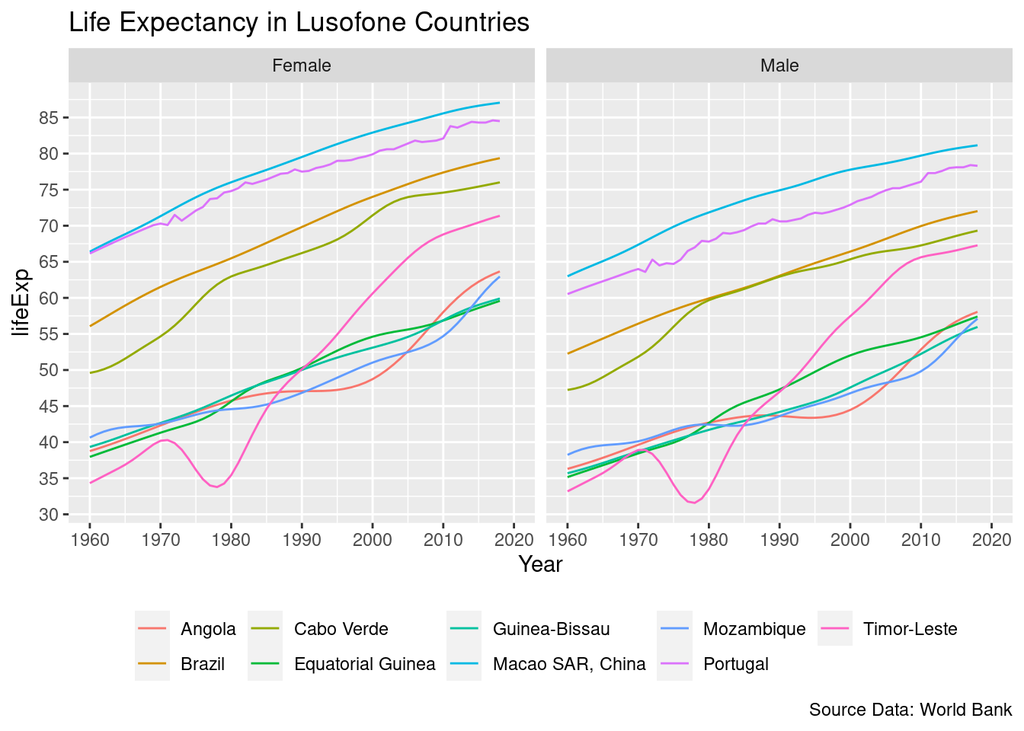

## Table - Spread by Year

**… Write your R code here …**

| Country | 1960_Female | 1960_Male | 2018_Female | 2018_Male |
| --- | --- | --- | --- | --- |
| Angola | 38.8 | 36.3 | 63.7 | 58.1 |
| Brazil | 56.1 | 52.3 | 79.4 | 72.0 |
| Cabo Verde | 49.6 | 47.2 | 76.0 | 69.3 |
| Equatorial Guinea | 38.0 | 35.2 | 59.6 | 57.4 |
| Guinea-Bissau | 39.3 | 35.7 | 59.9 | 56.0 |
| Macao SAR, China | 66.4 | 63.0 | 87.1 | 81.1 |
| Mozambique | 40.6 | 38.2 | 63.0 | 57.1 |
| Portugal | 66.2 | 60.5 | 84.5 | 78.3 |
| Timor-Leste | 34.3 | 33.2 | 71.4 | 67.3 |

## Table - Spread by Country

**… Write your R code here …**

| Year | Sex | Angola | Brazil | Cabo Verde | Equatorial Guinea | Guinea-Bissau | Macao SAR, China | Mozambique | Portugal | Timor-Leste |
| --- | --- | --- | --- | --- | --- | --- | --- | --- | --- | --- |
| 1960 | Female | 38.8 | 56.1 | 49.6 | 38.0 | 39.3 | 66.4 | 40.6 | 66.2 | 34 |
| 1960 | Male | 36.3 | 52.3 | 47.2 | 35.2 | 35.7 | 63.0 | 38.2 | 60.5 | 33 |
| 2018 | Female | 63.7 | 79.4 | 76.0 | 59.6 | 59.9 | 87.1 | 63.0 | 84.5 | 71 |
| 2018 | Male | 58.1 | 72.0 | 69.3 | 57.4 | 56.0 | 81.1 | 57.1 | 78.3 | 67 |